# Assessment 1

Nandani – S4627426

28th Aug 2022

# RMarkdown editing

**R Markdown** is a file format that is used in Rstudio to produce dynamic documents, which contains Markdown and R code. It creates an easy way for writing by using plain text format, and simply reading through common output format such as `html`. *For more details please click [here](https://rmarkdown.rstudio.com/lesson-8.html)!*

### **Part 1** - Insert an R chunk and create a variable with the dataset.The name of the variable should be `fastfood`.

```r
library(tidyverse)
library(knitr)
fastfood <- read_csv('fastfood_calories.csv')
```

```
## ──────────────────────────────────────────────────────── Delimiter: "," chr
## (3): restaurant, item, salad dbl (15): ...1, calories, cal_fat, total_fat,
## sat_fat, trans_fat, cholestero...
```

Display the first 10 rows of the dataset.

```r
head(fastfood, 10) %>%    kable()
```

| …1 | restaurant | item | calories | cal_fat | total_fat | sat_fat | trans_fat | cholesterol | sodium | total_carb | fiber | sugar | protein | vit_a | vit_c | calcium | salad |
| --- | --- | --- | --- | --- | --- | --- | --- | --- | --- | --- | --- | --- | --- | --- | --- | --- | --- |
| 1 | Mcdonalds | Artisan Grilled Chicken Sandwich | 380 | 60 | 7 | 2 | 0.0 | 95 | 1110 | 44 | 3 | 11 | 37 | 4 | 20 | 20 | Other |
| 2 | Mcdonalds | Single Bacon Smokehouse Burger | 840 | 410 | 45 | 17 | 1.5 | 130 | 1580 | 62 | 2 | 18 | 46 | 6 | 20 | 20 | Other |
| 3 | Mcdonalds | Double Bacon Smokehouse Burger | 1130 | 600 | 67 | 27 | 3.0 | 220 | 1920 | 63 | 3 | 18 | 70 | 10 | 20 | 50 | Other |
| 4 | Mcdonalds | Grilled Bacon Smokehouse Chicken Sandwich | 750 | 280 | 31 | 10 | 0.5 | 155 | 1940 | 62 | 2 | 18 | 55 | 6 | 25 | 20 | Other |
| 5 | Mcdonalds | Crispy Bacon Smokehouse Chicken Sandwich | 920 | 410 | 45 | 12 | 0.5 | 120 | 1980 | 81 | 4 | 18 | 46 | 6 | 20 | 20 | Other |
| 6 | Mcdonalds | Big Mac | 540 | 250 | 28 | 10 | 1.0 | 80 | 950 | 46 | 3 | 9 | 25 | 10 | 2 | 15 | Other |
| 7 | Mcdonalds | Cheeseburger | 300 | 100 | 12 | 5 | 0.5 | 40 | 680 | 33 | 2 | 7 | 15 | 10 | 2 | 10 | Other |
| 8 | Mcdonalds | Classic Chicken Sandwich | 510 | 210 | 24 | 4 | 0.0 | 65 | 1040 | 49 | 3 | 6 | 25 | 0 | 4 | 2 | Other |
| 9 | Mcdonalds | Double Cheeseburger | 430 | 190 | 21 | 11 | 1.0 | 85 | 1040 | 35 | 2 | 7 | 25 | 20 | 4 | 15 | Other |
| 10 | Mcdonalds | Double Quarter Pounder® with Cheese | 770 | 400 | 45 | 21 | 2.5 | 175 | 1290 | 42 | 3 | 10 | 51 | 20 | 6 | 20 | Other |

Display the first 10 rows of the dataset and the first 5 variables using kable() function.

```r
kable(fastfood[1:10, 1:5])
```

| …1 | restaurant | item | calories | cal_fat |
| --- | --- | --- | --- | --- |
| 1 | Mcdonalds | Artisan Grilled Chicken Sandwich | 380 | 60 |
| 2 | Mcdonalds | Single Bacon Smokehouse Burger | 840 | 410 |
| 3 | Mcdonalds | Double Bacon Smokehouse Burger | 1130 | 600 |
| 4 | Mcdonalds | Grilled Bacon Smokehouse Chicken Sandwich | 750 | 280 |
| 5 | Mcdonalds | Crispy Bacon Smokehouse Chicken Sandwich | 920 | 410 |
| 6 | Mcdonalds | Big Mac | 540 | 250 |
| 7 | Mcdonalds | Cheeseburger | 300 | 100 |
| 8 | Mcdonalds | Classic Chicken Sandwich | 510 | 210 |
| 9 | Mcdonalds | Double Cheeseburger | 430 | 190 |
| 10 | Mcdonalds | Double Quarter Pounder® with Cheese | 770 | 400 |

# Part-2

- Save observations with more than 40 in total_fat and more than 80 in total_carb in a new variable called `dont_eat_this`.

```r
dont_eat_this <-fastfood %>% filter(total_fat> 40 & total_carb> 80)
fastfood %>% filter(total_fat> 40 & total_carb> 80) %>% kable()
```

| …1 | restaurant | item | calories | cal_fat | total_fat | sat_fat | trans_fat | cholesterol | sodium | total_carb | fiber | sugar | protein | vit_a | vit_c | calcium | salad |
| --- | --- | --- | --- | --- | --- | --- | --- | --- | --- | --- | --- | --- | --- | --- | --- | --- | --- |
| 5 | Mcdonalds | Crispy Bacon Smokehouse Chicken Sandwich | 920 | 410 | 45 | 12 | 0.5 | 120 | 1980 | 81 | 4 | 18 | 46 | 6 | 20 | 20 | Other |
| 40 | Mcdonalds | 20 piece Buttermilk Crispy Chicken Tenders | 2430 | 1270 | 141 | 24 | 2.0 | 475 | 6080 | 103 | 2 | 3 | 186 | 0 | 2 | 8 | Other |
| 45 | Mcdonalds | 40 piece Chicken McNuggets | 1770 | 960 | 107 | 18 | 0.5 | 295 | 3370 | 105 | 7 | 1 | 98 | 0 | 15 | 6 | Other |
| 48 | Mcdonalds | 10 piece Sweet N’ Spicy Honey BBQ Glazed Tenders | 1600 | 600 | 66 | 10 | 0.0 | 265 | 4450 | 156 | 5 | 87 | 97 | 8 | 40 | 10 | Other |
| 121 | Sonic | 3 Piece Super Crunch Chicken Strip Dinner | 970 | 410 | 46 | 8 | 1.0 | 55 | 2160 | 109 | 7 | 9 | 30 | 1 | 6 | 13 | Other |
| 122 | Sonic | 4 Piece Super Crunch Chicken Strip Dinner | 1080 | 460 | 51 | 9 | 1.0 | 75 | 2390 | 118 | 8 | 9 | 37 | 1 | 7 | 13 | Other |
| 123 | Sonic | 5 Piece Super Crunch Chicken Strip Dinner | 1190 | 510 | 57 | 10 | 1.0 | 90 | 2610 | 126 | 8 | 9 | 44 | 2 | 8 | 14 | Other |
| 161 | Arbys | Pecan Chicken Salad Sandwich | 840 | 400 | 44 | 6 | 0.5 | 75 | 1210 | 81 | 6 | 20 | 33 | 10 | 8 | 25 | Other |
| 176 | Arbys | Triple Decker Sandwich | 1030 | 459 | 51 | 17 | 1.0 | 155 | 2940 | 83 | 5 | 19 | 62 | NA | NA | NA | Other |
| 270 | Dairy Queen | 4 Piece Chicken Strip Basket w/ Country Gravy | 1030 | 480 | 53 | 9 | 1.0 | 80 | 2780 | 105 | 9 | 4 | 35 | 2 | 0 | 10 | Other |
| 271 | Dairy Queen | 6 Piece Chicken Strip Basket w/ Country Gravy | 1260 | 590 | 66 | 11 | 1.0 | 120 | 3500 | 121 | 12 | 4 | 49 | 2 | 0 | 10 | Other |
| 291 | Dairy Queen | Steak Finger Basket | 910 | 430 | 48 | 13 | 0.5 | 45 | 2210 | 95 | 5 | 2 | 23 | NA | NA | NA | Other |
| 310 | Subway | Footlong Big Hot Pastrami | 1160 | 620 | 62 | 22 | 0.0 | 170 | 2940 | 94 | 10 | 14 | 58 | 20 | 90 | 80 | Other |
| 319 | Subway | Footlong Carved Turkey & Bacon w/ Cheese | 1140 | 460 | 52 | 14 | 0.0 | 140 | 3200 | 92 | 10 | 16 | 66 | 20 | 40 | 80 | Other |
| 321 | Subway | Footlong Chicken & Bacon Ranch Melt | 1140 | 500 | 56 | 20 | 2.0 | 190 | 2160 | 94 | 10 | 16 | 70 | 30 | 50 | 100 | Other |
| 331 | Subway | Footlong Italian Hero | 1100 | 520 | 58 | 20 | 0.0 | 150 | 2940 | 94 | 10 | 18 | 52 | 20 | 40 | 80 | Other |
| 342 | Subway | Footlong Spicy Italian | 960 | 440 | 48 | 18 | 2.0 | 100 | 3040 | 92 | 10 | 16 | 40 | 16 | 40 | 60 | Other |
| 354 | Subway | Footlong Tuna | 940 | 420 | 48 | 8 | 0.0 | 60 | 1240 | 88 | 10 | 12 | 40 | 16 | 40 | 60 | Other |
| 363 | Subway | Footlong Turkey Italiano Melt (with Provolone) | 980 | 420 | 48 | 18 | 2.0 | 100 | 2960 | 94 | 10 | 16 | 48 | 20 | 40 | 90 | Other |
| 431 | Taco Bell | XXL Grilled Stuft Burrito - Beef | 880 | 380 | 42 | 14 | 1.0 | 75 | 2020 | 94 | 12 | 6 | 31 | NA | NA | NA | Other |

- Show the count of observations for each restaurant.

```r
fastfood %>%   count(restaurant, wt = NULL, sort = TRUE, name = "res_num") %>%    kable()
```

| restaurant | res_num |
| --- | --- |
| Taco Bell | 115 |
| Subway | 96 |
| Burger King | 70 |
| Mcdonalds | 57 |
| Arbys | 55 |
| Sonic | 53 |
| Dairy Queen | 42 |
| Chick Fil-A | 27 |

- Using grouppings `group_by()`, summarise and display the average number of calories for each restaurant.

```r
fastfood%>%   group_by(restaurant)%>%

summarise(average_cal = mean(calories, trim = 0, na.rm = FALSE)) %>%    ungroup() %>%  kable()
```

| restaurant | average_cal |
| --- | --- |
| Arbys | 532.7273 |
| Burger King | 608.5714 |
| Chick Fil-A | 384.4444 |
| Dairy Queen | 520.2381 |
| Mcdonalds | 640.3509 |
| Sonic | 631.6981 |
| Subway | 503.0208 |
| Taco Bell | 443.6522 |

- Add a variable to the dataset, which calculates the average calories per type of restaurant and call it `average_calories`

```r
average_calories <-   fastfood %>%    group_by(restaurant)%>%   mutate(average_calories = mean(calories)) %>%    ungroup()
head(average_calories %>% select(restaurant,calories,average_calories))
```

```
## # A tibble: 6 × 3
##   restaurant calories average_calories
##   <chr>         <dbl>            <dbl>
## 1 Mcdonalds       380             640.
## 2 Mcdonalds       840             640.
## 3 Mcdonalds      1130             640.
## 4 Mcdonalds       750             640.
## 5 Mcdonalds       920             640.
## 6 Mcdonalds       540             640.
```

- Display the data vis of total fat per each type of restaurant. Write a narration (2-3 sentences) why you believe this type of data viz presents such information best.

- Add a variable to the dataset, which calculates the maximum total fat per type of restaurant and call it `max_total_fat`.

```r
max_total_fat <- fastfood %>%    group_by(restaurant) %>%   mutate(max_total_fat = max(total_fat)) %>%    ungroup()
head(max_total_fat %>% select(restaurant,item,total_fat,max_total_fat))
```

```
## # A tibble: 6 × 4
##   restaurant item                                      total_fat max_total_fat
##   <chr>      <chr>                                         <dbl>         <dbl>
## 1 Mcdonalds  Artisan Grilled Chicken Sandwich                  7           141
## 2 Mcdonalds  Single Bacon Smokehouse Burger                   45           141
## 3 Mcdonalds  Double Bacon Smokehouse Burger                   67           141
## 4 Mcdonalds  Grilled Bacon Smokehouse Chicken Sandwich        31           141
## 5 Mcdonalds  Crispy Bacon Smokehouse Chicken Sandwich         45           141
## 6 Mcdonalds  Big Mac                                          28           141
```

- Use observations for Mcdonalds to plot sugar variable against protein with `geom_point()`.

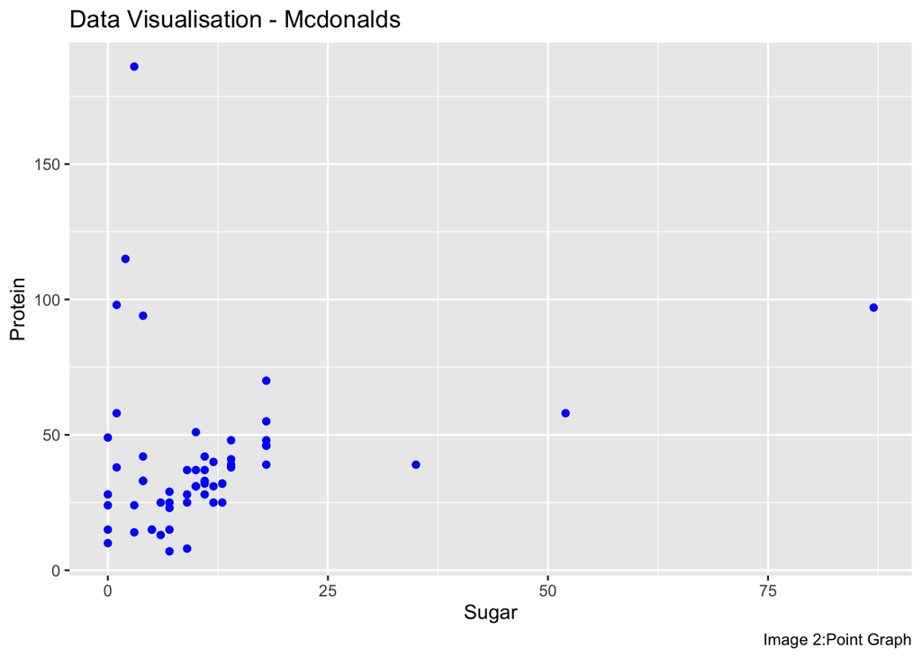

```r
fastfood %>%    select(restaurant, sugar, protein) %>%    filter(restaurant=="Mcdonalds") %>%    ggplot(aes(sugar,protein)) +   geom_point(colour = "blue") +   labs(x="Sugar", y="Protein", title = "Data Visualisation - Mcdonalds", caption = "Image 2:Point Graph")
```

# Part-3

- Identify variable(s) which should be factors and transform their type into a factor variable.

```r
#install.packages("forcats")
library(forcats)
is.factor(fastfood$restaurant)
```

```
## [1] FALSE
```

```r
as.factor(fastfood$restaurant)
```

[output not shown]

[output cut: 72 more lines]

- Add a new variable to the dataset `calories_type` using `cut_number()` function.Use `calories` variable for `cut_number()` function to split it into 3 categories `n=3`, add labels `labels=c("low", "med", "high")` and make the dataset ordered.

```r
calories_type <- fastfood %>%
group_by(restaurant) %>%
mutate(calories_type = cut_number(calories, n = 3, labels = c("low","med","high"))) %>%    ungroup() %>%
arrange(calories_type)
head(calories_type %>%
select(restaurant,item,calories,calories_type))
```

```
## # A tibble: 6 × 4
##   restaurant item                             calories calories_type
##   <chr>      <chr>                               <dbl> <fct>
## 1 Mcdonalds  Artisan Grilled Chicken Sandwich      380 low
## 2 Mcdonalds  Cheeseburger                          300 low
## 3 Mcdonalds  Double Cheeseburger                   430 low
## 4 Mcdonalds  Filet-O-Fish®                         380 low
## 5 Mcdonalds  Hamburger                             250 low
## 6 Mcdonalds  Lobster Roll                          290 low
```

- Create a data viz that shows the distribution of `calories_type` in food items for each type of restaurant.Think carefully about the choice of data viz. Use facets, coordinates and theme layers to make your data viz visually appealing and meaningful. Use factors related data viz functions.

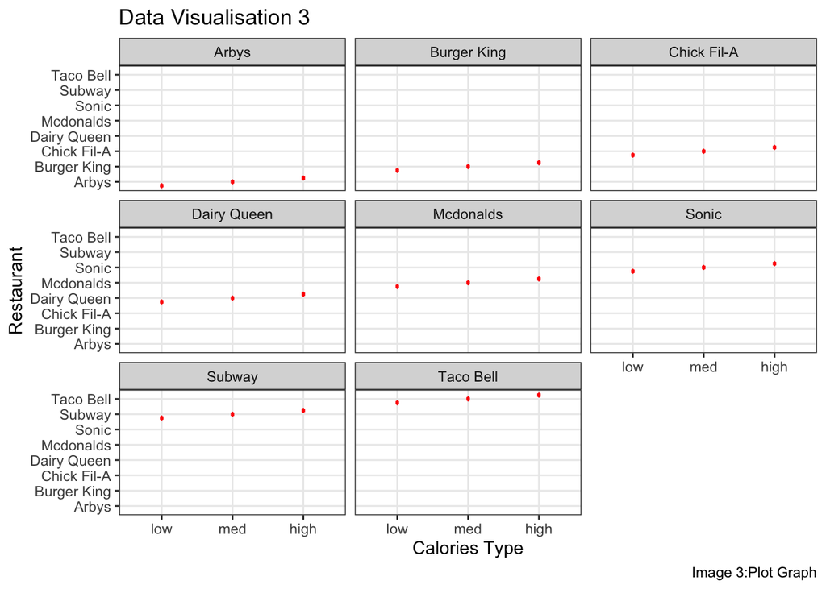

```r
calories_type %>%
group_by(restaurant) %>%
ungroup() %>%

ggplot(aes(restaurant, calories_type)) +   geom_boxplot(colour="red") +   facet_wrap(vars(restaurant)) +   coord_flip() +   theme_bw() +   labs(x="Restaurant", y="Calories Type", title ="Data Visualisation 3", caption = "Image 3:Plot Graph")
```

- Show the percentage of `trans_fat` in `total_fat` and add the variable to the dataset and call it `trans_fat_percent`.

```r
trans_fat_percent <- fastfood %>%

group_by(restaurant) %>%

mutate(trans_fat_percent = trans_fat / total_fat * 100) %>%

ungroup()

head(trans_fat_percent %>% select(restaurant,item,trans_fat,total_fat,trans_fat_percent)) #round(trans_fat_percent$trans_fat_percent, 2)
```

```
## # A tibble: 6 × 5
##   restaurant item                                      trans_fat total…¹ trans…²
##   <chr>      <chr>                                         <dbl>   <dbl>   <dbl>
## 1 Mcdonalds  Artisan Grilled Chicken Sandwich                0         7    0
## 2 Mcdonalds  Single Bacon Smokehouse Burger                  1.5      45    3.33
## 3 Mcdonalds  Double Bacon Smokehouse Burger                  3        67    4.48
## 4 Mcdonalds  Grilled Bacon Smokehouse Chicken Sandwich       0.5      31    1.61
## 5 Mcdonalds  Crispy Bacon Smokehouse Chicken Sandwich        0.5      45    1.11
## 6 Mcdonalds  Big Mac                                         1        28    3.57
## # … with abbreviated variable names ¹total_fat, ²trans_fat_percent
```

- Create a data viz that shows the distribution of `trans_fat` in food items for each type of restaurant.Think carefully about the choice of data viz. Use facets, coordinates and theme layers to make your data viz visually appealing and meaningful.

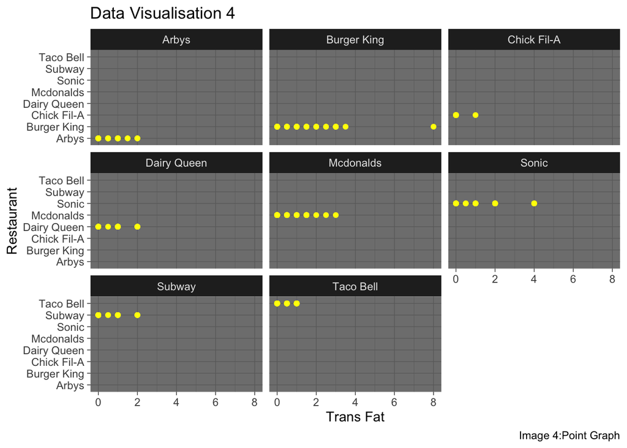

```r
ggplot(fastfood, aes(restaurant,trans_fat)) +   geom_point(colour = "yellow") +   facet_wrap(vars(restaurant)) +   coord_flip() +   labs(x="Restaurant", y="Trans Fat", title = "Data Visualisation 4", caption = "Image 4:Point Graph") +   theme_dark()
```

- Calculate and show the average (mean) `total_fat` for each type of restaurant. No need to save it as a variable.

```r
fastfood %>%    group_by(restaurant) %>%    summarise(average_fat = mean(total_fat)) %>%    ungroup() %>%    kable()
```

| restaurant | average_fat |
| --- | --- |
| Arbys | 26.98182 |
| Burger King | 36.81429 |
| Chick Fil-A | 16.14815 |
| Dairy Queen | 28.85714 |
| Mcdonalds | 31.80702 |
| Sonic | 37.64151 |
| Subway | 18.47917 |
| Taco Bell | 20.89565 |

- Create a dataviz that allow to compare different restaurants on this variable (`total_fat`). You can present it on one dataviz (= no facets).

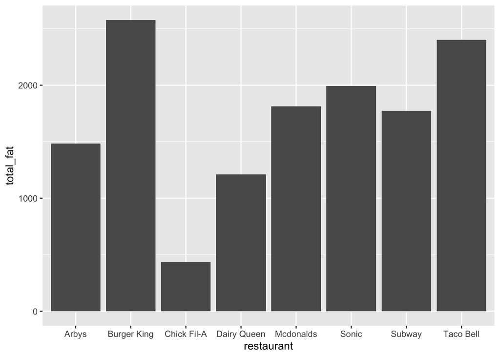

```r
ggplot(fastfood, aes(restaurant,total_fat)) + geom_col()
```

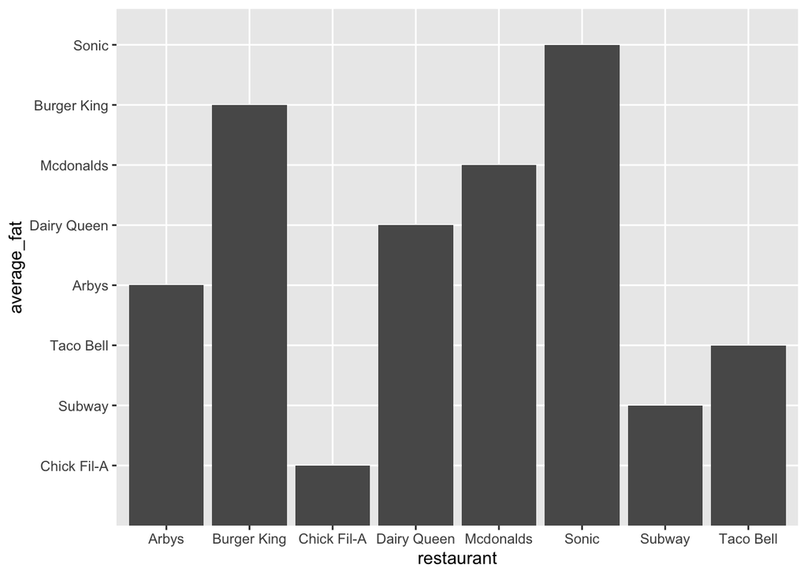

```r
fastfood %>%

group_by(restaurant) %>%

summarise(average_fat = mean(total_fat)) %>%    ungroup() %>%

mutate(average_fat = fct_reorder(restaurant,average_fat)) %>%

ggplot(aes(restaurant,average_fat)) +   geom_col()
```